# Praca domowa 2

Paweł Pawlukiewicz

## Dane

Dane wykorzystane w Pracy domowej 2 dotyczą wyników egzaminów z 3 umiejętności: czytania, pisania i operacji matematycznych. Dodatkowo dostępne są podstawowe informacje o studentach i ich rodzicach. Opis wszystkich kolumn znajduje się również w pliku `README.md`.

| Zmienna | Opis |
| --- | --- |
| **gender** | płeć |
| **race.ethnicity** | pochodzenie etniczne |
| **parental.level.of.education** | wykształcenie rodziców |
| **lunch** | jaki obiad jedli uczniowie w dniu egzaminu |
| **test.preparation.course** | czy uczeń odbył kurs przygotowujący |
| **math.score** | wynik egzaminu z matematyki |
| **reading.score** | wynik egzaminu z czytania |
| **writing.score** | wynik egzaminu z pisania |

## Zadanie 1

Jak wyglądają rozkłady wyników uczniów z trzech przedmiotów (matematyka, czytanie, pisanie)?

```r
# Tu umieść kod do wygenerowania odpowiedzi do zadania.
library(tidyr)
```

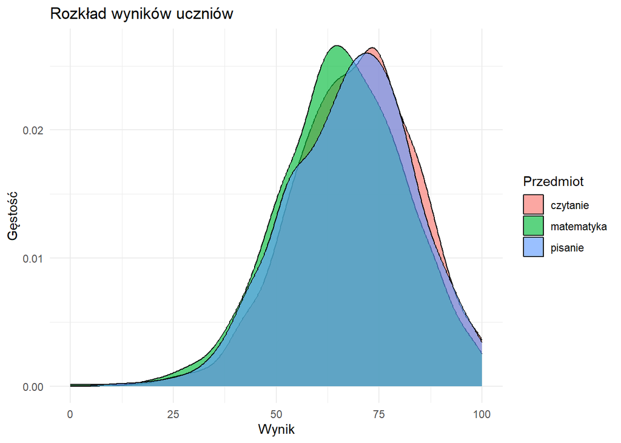

```r
names(df) <- c("plec", "pochodzenie_etniczne", "wyksztalcenie_rodziców", "lunch", "kurs", "matematyka", "czytanie","pisanie")

divided_df <- df %>%
  pivot_longer(
    cols = c(matematyka, czytanie, pisanie),
    names_to = "przedmiot",
    values_to = "wynik"
  )

ggplot(divided_df,aes(x=wynik, fill = przedmiot)) +
  geom_density(alpha=0.64) +
  labs(title = "Rozkład wyników uczniów",
       x = "Wynik",
       y = "Gęstość",
       fill = "Przedmiot") +
  theme_minimal()
```

**Komentarz:** Ogólnie rozkłady wyników uczniów są zbliżone. Matematyka ma w porównaniu z pisaniem i czytaniem rozkład najbardziej przesunięty w lewą stronę, moda z tego przedmiotu to ok. 65, a z pozostałych 2 jest to bliżej wyniku 70. Jeżeli chodzi o pisanie i czytanie to ich rozkłady są bardzo podobne, z tą różnicą, że pisanie ma więcej niższych wyników.

## Zadanie 2

Czy istnieje zauważalna różnica w wynikach między uczniami i uczennicami?

```r
# Tu umieść kod do wygenerowania odpowiedzi do zadania.
names(divided_df)
```

```
## [1] "plec"                   "pochodzenie_etniczne"   "wyksztalcenie_rodziców"
## [4] "lunch"                  "kurs"                   "przedmiot"
## [7] "wynik"
```

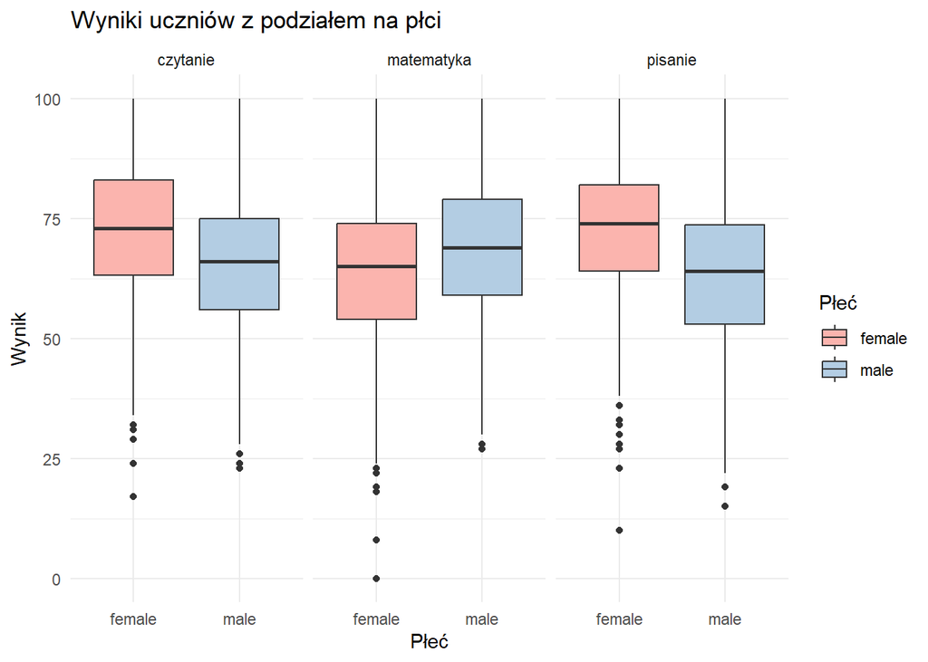

```r
ggplot(divided_df, aes(x = plec, y = wynik, fill = plec)) +
  geom_boxplot() +
  facet_wrap(~ przedmiot) +
  labs(title = "Wyniki uczniów z podziałem na płci",
       x = "Płeć",
       y = "Wynik",
       fill = "Płeć") +
  scale_fill_brewer(palette = "Pastel1") +
  theme_minimal()
```

**Komentarz:** Tak, dziewczyny mają znacznie lepsze wyniki od chłopców jeżeli chodzi o egzamin z pisania, nieco lepsze wyniki z egzaminu z czytania, a chłopcy górują nad dziewczynami w wynikach egzaminu z matematyki. Warto też dodać, że wyniki chłopców są bardziej “równe” i nie ma dużo wyników znacznie odstających od normy, jednak u dziewczyn zauważalna jest liczbą wyników niskich, odstających od normy.

## Zadanie 3

Czy uczniowie, którzy ukończyli kurs przygotowawczy, osiągają lepsze wyniki niż pozostali?

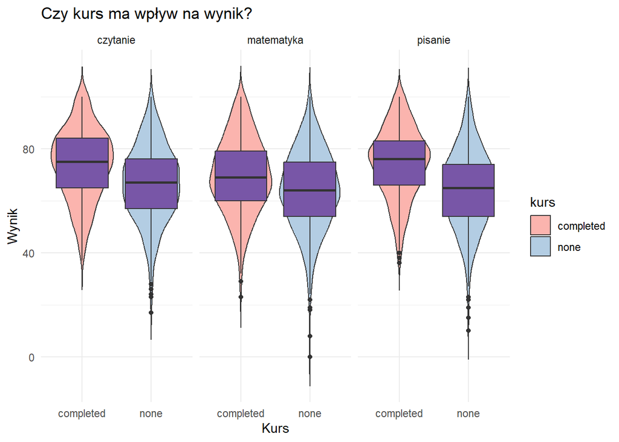

```r
# Tu umieść kod do wygenerowania odpowiedzi do zadania.

ggplot(divided_df, aes(x = kurs, y = wynik, fill = kurs)) +
  geom_violin(trim = FALSE) +
  geom_boxplot(fill = "#7856a7") +
  facet_wrap(~ przedmiot) +
  labs(title = "Czy kurs ma wpływ na wynik?",
       x = "Kurs",
       y = "Wynik") +
  scale_fill_brewer(palette = "Pastel1") +
  theme_minimal()
```

Jaki jest związek między poziomem wykształcenia rodziców a średnimi wynikami uczniów?

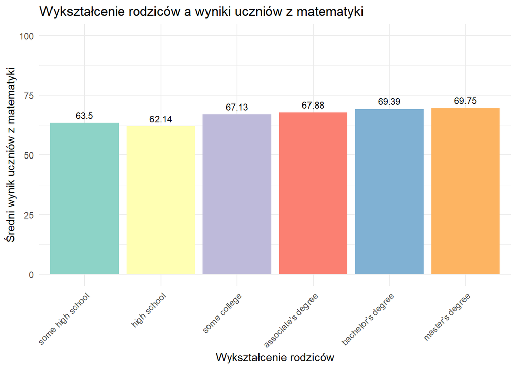

```r
# Tu umieść kod do wygenerowania odpowiedzi do zadania.
poziomy_edukacji <- c("some high school", "high school", "some college",
                     "associate's degree", "bachelor's degree", "master's degree")

df_z4 <- df %>%
  mutate(wyksztalcenie_rodziców = factor(wyksztalcenie_rodziców, levels = poziomy_edukacji)) %>%
  group_by(wyksztalcenie_rodziców) %>%
  summarise(mean_mat = mean(matematyka),
            mean_czy = mean(czytanie),
            mean_pis = mean(pisanie))


p1 <- ggplot(df_z4, aes(x=wyksztalcenie_rodziców, y=mean_mat, fill = wyksztalcenie_rodziców)) +
  geom_col(show.legend = FALSE) +
  geom_text(aes(label = round(mean_mat,2)),
            vjust=-0.6,
            size = 3) +
  scale_fill_brewer(palette = "Set3") +
  labs(title = "Wykształcenie rodziców a wyniki uczniów z matematyki",
       x = "Wykształcenie rodziców",
       y = "Średni wynik uczniów z matematyki") +
  theme_minimal() +
  theme(axis.text.x = element_text(angle = 45, hjust=1)) +
  scale_y_continuous(limits = c(0,100))

p2 <- ggplot(df_z4, aes(x=wyksztalcenie_rodziców, y=mean_czy, fill = wyksztalcenie_rodziców)) +
  geom_col(show.legend = FALSE) +
  geom_text(aes(label = round(mean_czy,2)),
            vjust=-0.6,
            size = 3) +
  scale_fill_brewer(palette = "Set3") +
  labs(title = "Wykształcenie rodziców a wyniki uczniów z czytania",
       x = "Wykształcenie rodziców",
       y = "Średni wynik uczniów z czytania") +
  theme_minimal() +
  theme(axis.text.x = element_text(angle = 45, hjust=1)) +
  scale_y_continuous(limits = c(0,100))

p3 <- ggplot(df_z4, aes(x=wyksztalcenie_rodziców, y=mean_pis, fill = wyksztalcenie_rodziców)) +
  geom_col(show.legend = FALSE) +
  geom_text(aes(label = round(mean_pis,2)),
            vjust=-0.6,
            size = 3) +
  scale_fill_brewer(palette = "Set3") +
  labs(title = "Wykształcenie rodziców a wyniki uczniów z pisania",
       x = "Wykształcenie rodziców",
       y = "Średni wynik uczniów z pisania") +
  theme_minimal() +
  theme(axis.text.x = element_text(angle = 45, hjust=1)) +
  scale_y_continuous(limits = c(0,100))

  p1
```

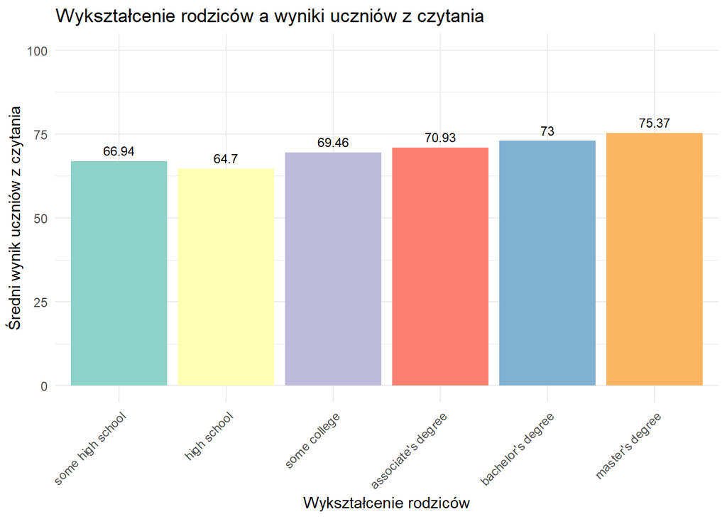

```r
  p2
```

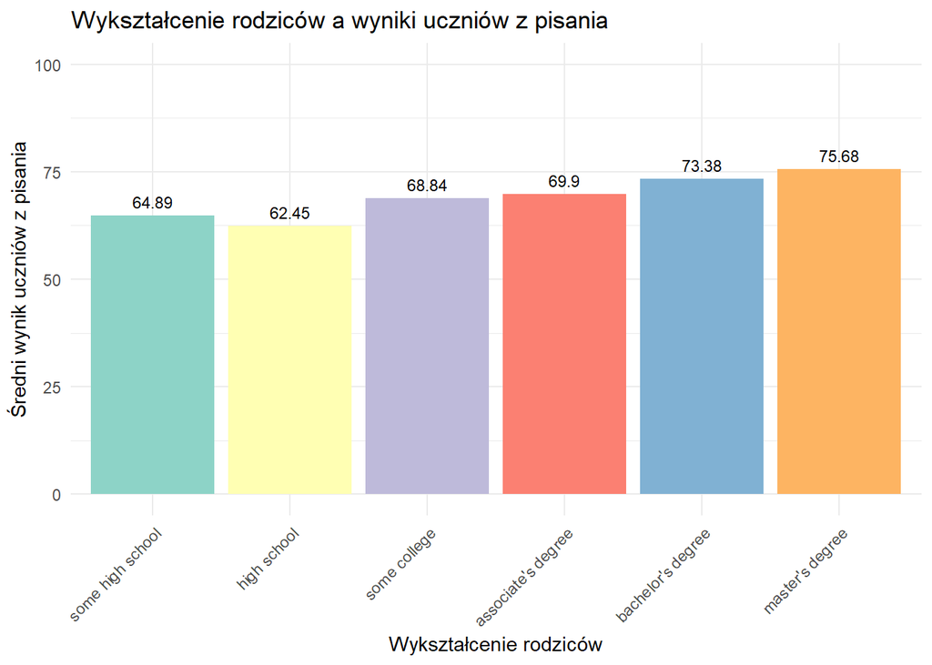

```r
  p3  # Trzeba odpalić wszystkie naraz wtedy pokażą się 3 wykresy dla 3 przedmiotów
```

**Komentarz:** Na wszystkich 3 wykresach widać związek między wykształceniem rodziców a średnimi wynikami uczniów (dzieci tych rodziców) z poszczególnych przedmiotów. Z wyjątkiem tego że dzieci rodziców z wykształceniem średnim niepełnym osiągają wyższe wyniki niż dzieci rodzicówz wykształceniem średnim pełnym, to związek jest taki, że im wyższe wykształcenie rodziców, tym wyższy średni wynik ich dzieci z egzaminów z wszytskich 3 przedmiotów.

## Zadanie 5

Czy płeć i wykształcenie rodzica wpływa na wynik z matematyki?

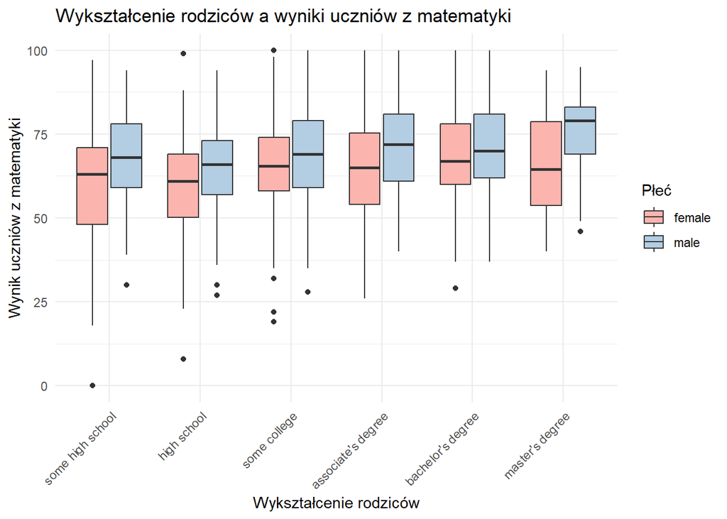

```r
# Tu umieść kod do wygenerowania odpowiedzi do zadania.

df5 <- df %>%
  mutate(wyksztalcenie_rodziców = factor(wyksztalcenie_rodziców, levels = poziomy_edukacji)) %>%
  select(matematyka, plec, wyksztalcenie_rodziców)

ggplot(df5, aes(x = wyksztalcenie_rodziców, y = matematyka, fill=plec)) +
  geom_boxplot() +
  scale_fill_brewer(palette = "Pastel1") +
  labs(title = "Wykształcenie rodziców a wyniki uczniów z matematyki",
       x = "Wykształcenie rodziców",
       y = "Wynik uczniów z matematyki",
       fill = "Płeć") +
  theme_minimal() +
  theme(axis.text.x = element_text(angle = 45, hjust=1))
```

## Zadanie 6

Czy istnieje zależność między wynikami z matematyki a wynikami z czytania lub pisania?

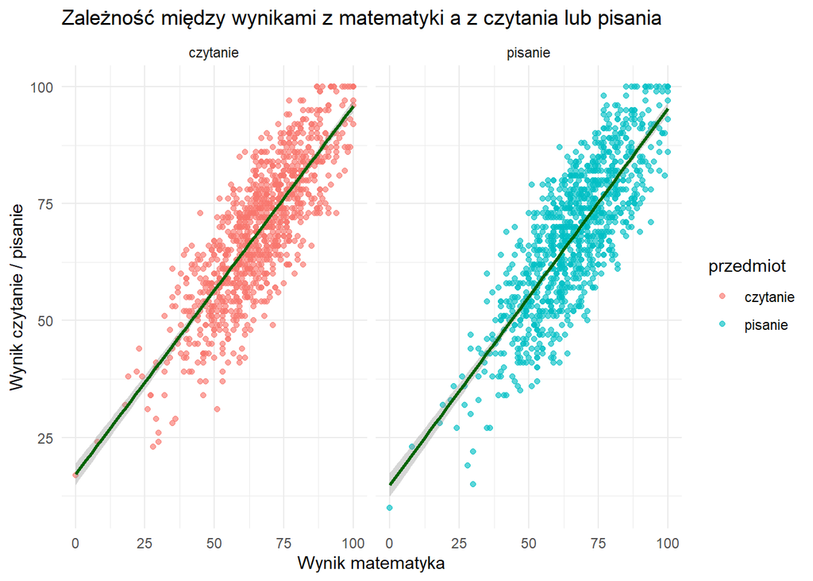

```r
# Tu umieść kod do wygenerowania odpowiedzi do zadania.

df_czyt_pis <- df %>%
  pivot_longer(cols = c(czytanie,pisanie),
               names_to = "przedmiot",
               values_to = "wynik_c_p")

ggplot(df_czyt_pis, aes(x = matematyka, y = wynik_c_p)) +
  geom_point(alpha = 0.64, aes(colour = przedmiot)) +
  facet_wrap(~ przedmiot) +
  geom_smooth(method = "lm", color = "darkgreen") +
  labs(title = "Zależność między wynikami z matematyki a z czytania lub pisania",
       x = "Wynik matematyka",
       y = "Wynik czytanie / pisanie") +
  theme_minimal()
```

**Komentarz:** Tak, widać bardzo silną zależność między wynikami z matematyki a wynikami z czytania i pisania. Można stwierdzić, że im wyższy wynik ucznia z matematyki tym lepszy wynik również z egzaminu z pisania lub czytania. Oczywiście im gorszy wynik z egzaminu z matemaryki, tym wynik z pozostałych 2 egzaminów również jest na ogół gorszy.